| title: “Homework Week 47” |
| --- |
| author: “Emil Jacobsen” |
| date: ” 2021/11/30” |
| output: |
| html_document: |
| toc: TRUE |
| toc_float: TRUE |

```r
library(tidyverse)
Western_Europe <- read_csv("data/homicide-rates-across-western-europe.csv")
names(Western_Europe)[1] <- 'country'
```

```r
head(Western_Europe)
```

```
## # A tibble: 6 x 4
##   country Code   Year Homicide_per_100k
##   <chr>   <chr> <dbl>             <dbl>
## 1 England <NA>   1300                23
## 2 England <NA>   1550                 7
## 3 England <NA>   1625                 6
## 4 England <NA>   1675                 4
## 5 England <NA>   1725                 2
## 6 England <NA>   1775                 1
```

# homework week 47

## chunk 1

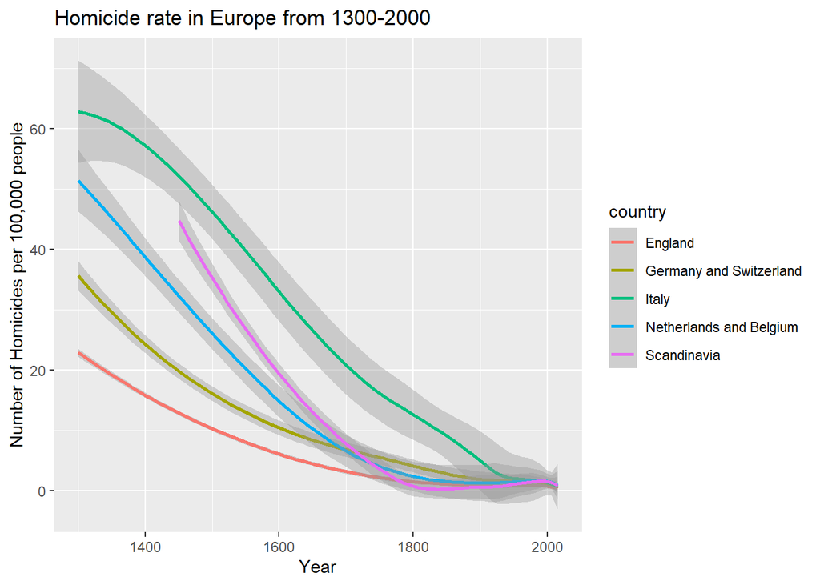

```r
ggplot(data = Western_Europe) +
  geom_smooth(mapping = aes(x = Year,
                           y = Western_Europe$Homicide_per_100k,
                           color = country)) +
  labs(x = "Year",
       y = "Number of Homicides per 100,000 people",
       title = "Homicide rate in Europe from 1300-2000")
```

## chunk 2

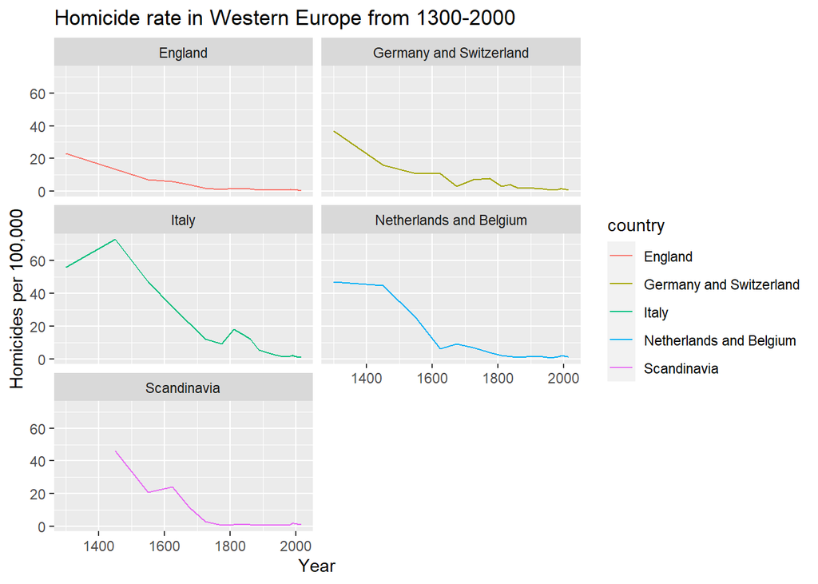

```r
ggplot(data = Western_Europe) +
  geom_line(mapping = aes(x = Year,
                           y = Western_Europe$Homicide_per_100k,,
                           color = country)) +
  facet_wrap(~ country, nrow = 3, ncol = 2) +
  labs(x = "Year",
       y = "Homicides per 100,000",
       title = "Homicide rate in Western Europe from 1300-2000")
```

```r
theme(legend.direction = "bottom")
```

```
## List of 1
##  $ legend.direction: chr "bottom"
##  - attr(*, "class")= chr [1:2] "theme" "gg"
##  - attr(*, "complete")= logi FALSE
##  - attr(*, "validate")= logi TRUE
```

## Kings plot

```r
kings <- read_csv("./Data/Exerxice-1-Ark1.csv")
kings$Duration <- kings$End_of_Reign-kings$Beginning_of_Reign
kings[30,1:6]
```

```
## # A tibble: 1 x 6
##   Sovereign    Born  Dead Beginning_of_Reign End_of_Reign Duration
##   <chr>       <dbl> <dbl>              <dbl>        <dbl>    <dbl>
## 1 Interregnum    NA    NA               1132         1340      208
```

```r
kings1 <- kings[-c(30,40),]

mean(kings1$Duration,na.rm=T)
```

```
## [1] 18.94118
```

```r
class(kings1$Duration)
```

```
## [1] "numeric"
```

```r
kings1 <- kings1 %>%
  mutate(midyear = Beginning_of_Reign -(Beginning_of_Reign-End_of_Reign)/2)
```

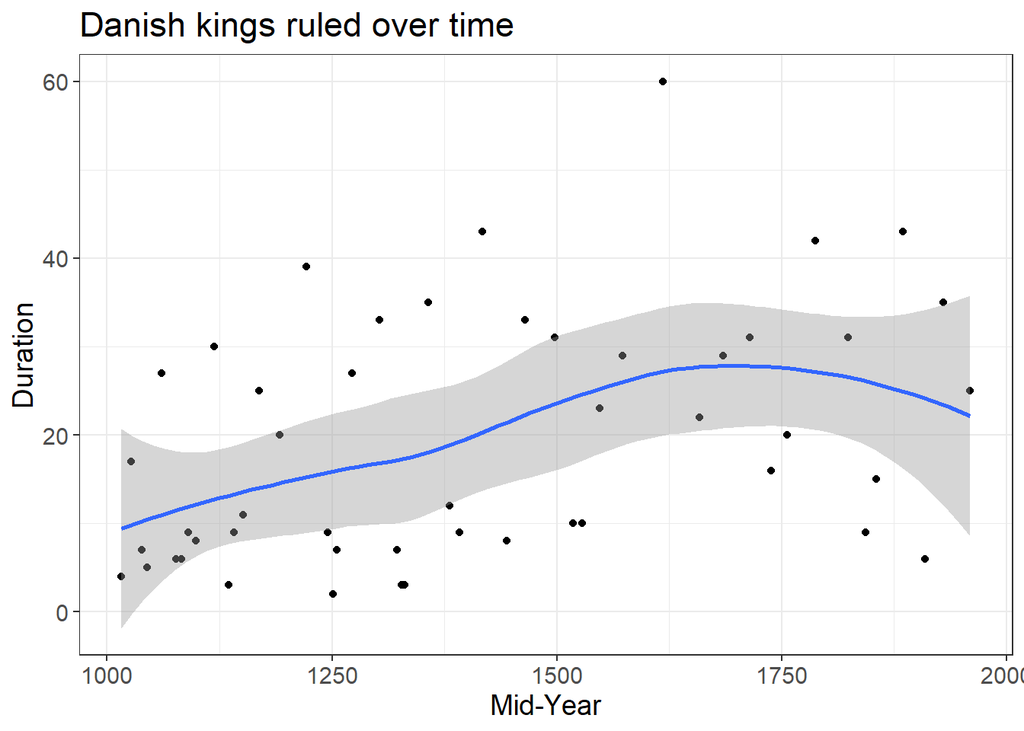

```r
ggplot(kings1, aes(x=midyear,y=Duration))+
  geom_point()+
  geom_smooth()+
  labs(title = "Danish kings ruled over time",
       x="Mid-Year",y="Duration")+
  theme_bw()+
  theme(text = element_text(size=14))
```

## opgave 1

replace the long column name with the simpler homicides_per_100k in both coding chunks (see above for ex)

## opgave 3

tried to use ncol to add an extra row, but it just made the ggplot longer haha (see chunk 2) facet_wrap(~ country, nrow = 3, ncol = 2)

## opgave 4

theme(legend.direction = “bottom”) tried to move the legend to the bottom of the plot by using this line of code in chunk 2, it not work

## opgave 5

title: “new homework week47” author: “Emil Jacobsen” date: “30/11/2021” output: html_document: toc: TRUE toc_float: TRUE

wrote this in the top of the Rmd, and then proceeded to make a heading by making 1 hashtag and 2 hastags for every other heading

## opgave 6

First we had to add a midyear column to the kings csv file, we did it with this:

kings1 <- kings1 %>% mutate(midyear = Beginning_of_Reign -(Beginning_of_Reign-End_of_Reign)/2)

then we had to set up the gg plot:

ggplot(kings1, aes(x=midyear,y=Duration))+ geom_point()+ geom_smooth()+ labs(title = “Danish kings ruled over time”, x=“Mid-Year”,y=“Duration”)+ theme_bw()+ theme(text = element_text(size=14))

it fricking worked

## opgave 7

While the data visualizations does show a significant decrease in murders, the concept of being civilized is man made and can therefore change over time. For that reason a decrease in murders doesn’t equal a more “civilized” society, just a less murdery one

**Your Tasks:**

1. the column name Western_Europe$`Homicide rate in Europe over long-term (per 100,000) is not very easy to work with. Relabel it to ‘homicides_per_100k’ inside R after loading the dataset and then edit all the ggplots.
2. The basic plot and following facet-plot (combination plot) is great, but geom_point - a scatterplot - is not the best choice for showing long-term data. Can you change both plots to more suitable type of rendering?
3. Can you change the facet “layout” to two columns and three rows so that the trends are easier to see?
4. Move the legend from the current position on the side to below the facets, and label it “Country” instead of “Entity”.
5. Add a floating table of contents to your Rmarkdown document, provide informative chunk-names to all your R chunks, and automatically generate a timestamp to show when the document was last updated. (Hint: check the Rmarkdown episode in our Data Carpentry tutorial)
6. Fill in the empty code chunk with a ggplot of your Danish kings: loading the data, calculating the mid-year, and plotting the duration of reign (y axis) over the mid-year (x axis), using geom_smooth()
7. Comment briefly what is your opinion on the basis of the data visualisations: are we more civilized today?